# Final Presentation

December 20, 2018

## Problem

Will Kobe make his shot?

We want to predict whether or not Kobe will make his shot.

- Will help us see which attributes are correlated with a successful shot
- Will help future athletes decide where/when/how to take their shots

[figure not shown]

## Dataset

Kobe Bryant Shot Selection

- 30697 observations (5000 of which are for testing purposes)
- 25 input variables (narrows down to 15)
- Target Variable: shot_made_flag = whether or not a shot was made

[figure not shown]

## Categorical Input Variables (10)

combined_shot_type = Ex. Jump Shot, bank shot

period = Period in the game

playoffs = Whether or not it was a playoff game

season = NBA season

shot_type = 2 pointer or 3 pointer

shot_zone_area = Ex. Center, Left, Right

shot-zone_basic = Ex. Paint, Corner 3, Mid-range

shot_zone_range = 8-16ft, 16-14ft

oppenent = Oppposing team

Home/Away = Whether game was home or away

## Numerical Input Variables (5)

loc_x = Location on width of court

loc_y = Location on length of court

shot_distance = How far away the shot was

game_date = date as integer

time_remaining_s = time remaining in period in seconds

[figure not shown]

## Data Exploration - Target Variable (44.62% positive rate)

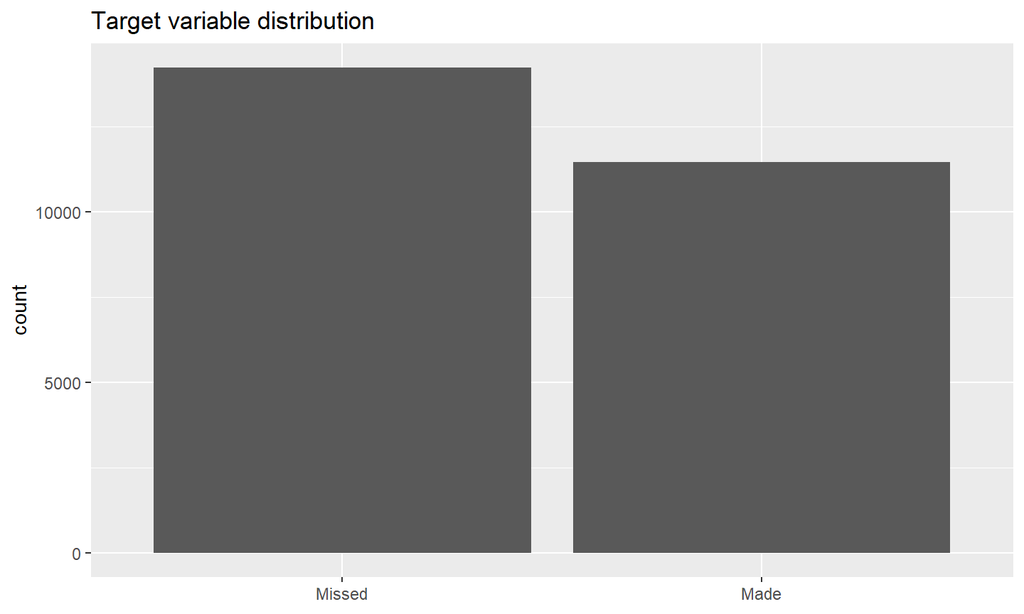

## Categorical Variables vs Target

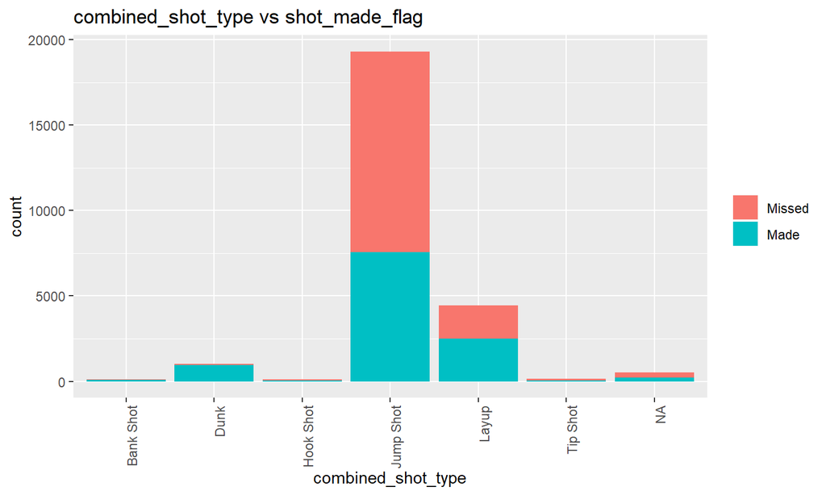

## Categorical Variables vs Target

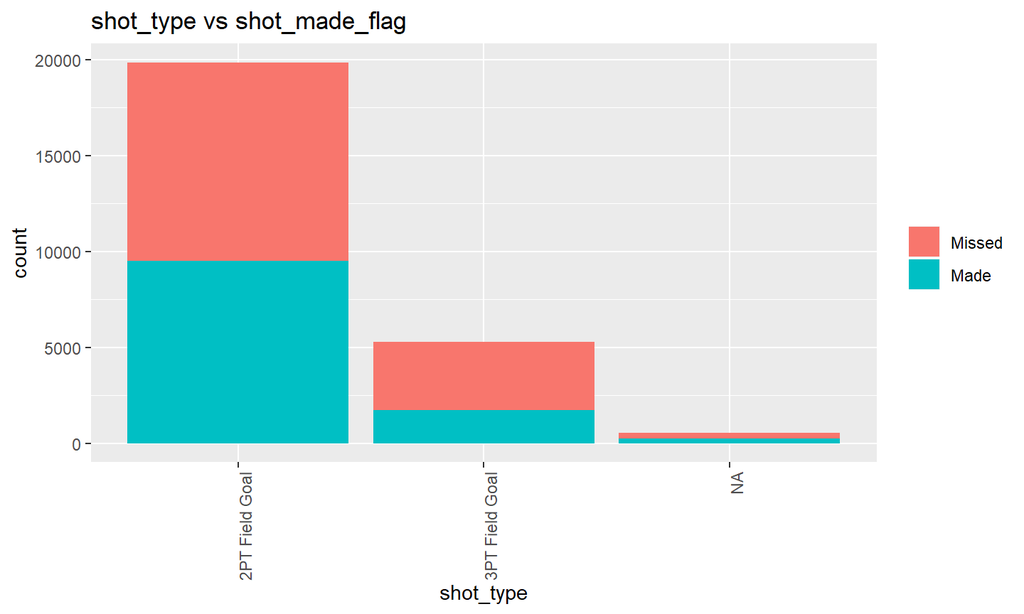

## Categorical Variables vs Target

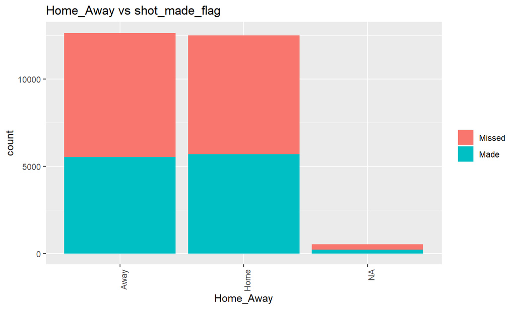

## Numeric Variables vs Target

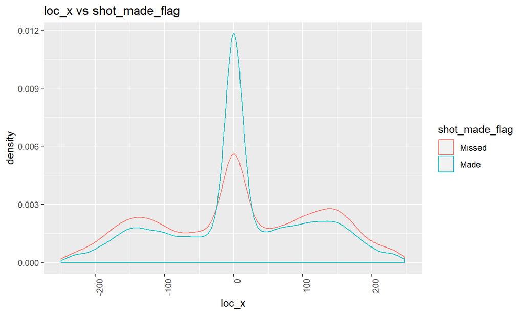

## Numeric Variables vs Target

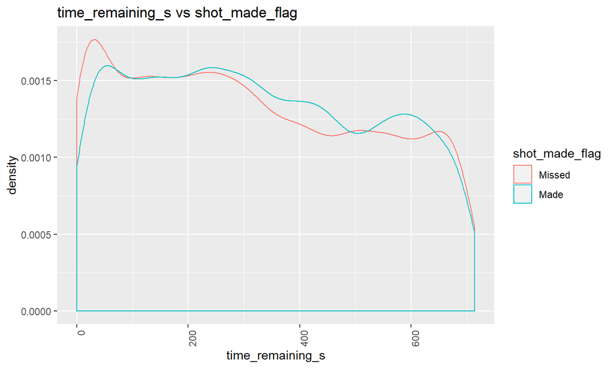

## Court vs categorical variables

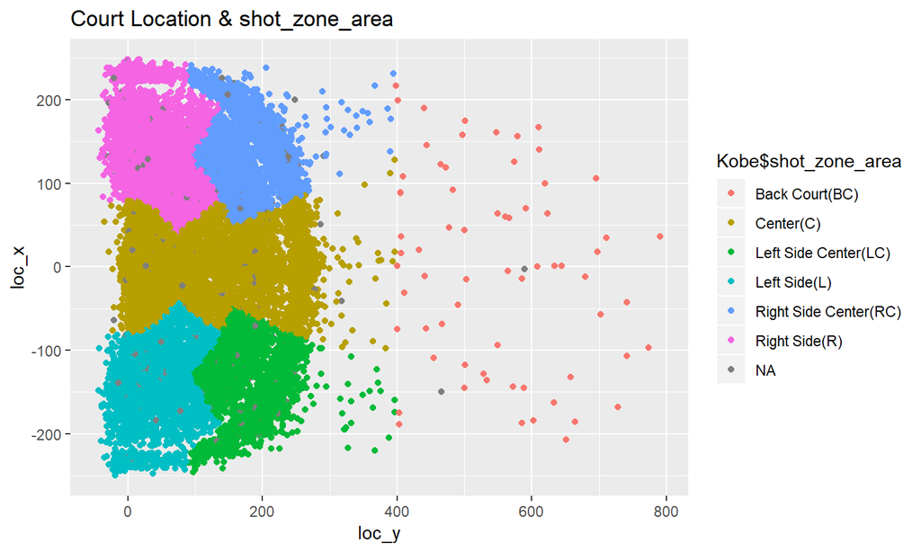

## Court vs categorical variables

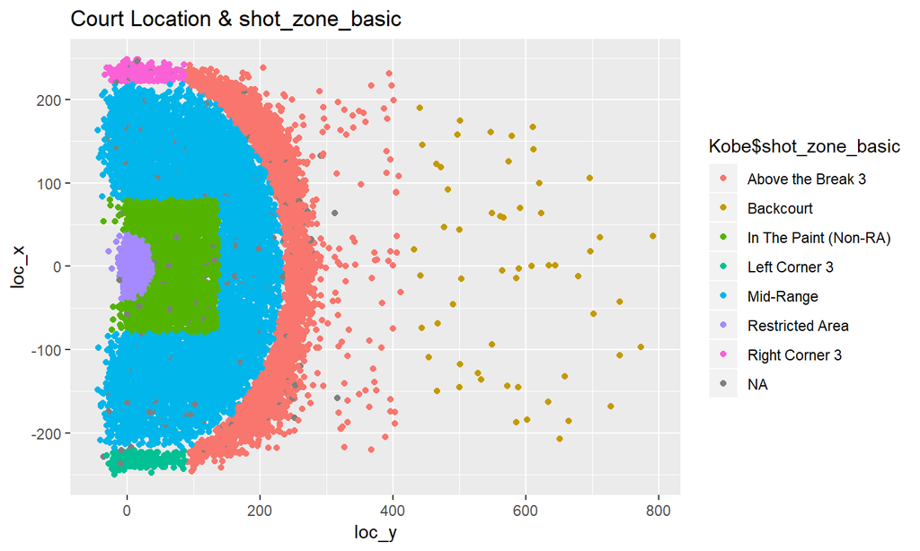

## Court vs categorical variables

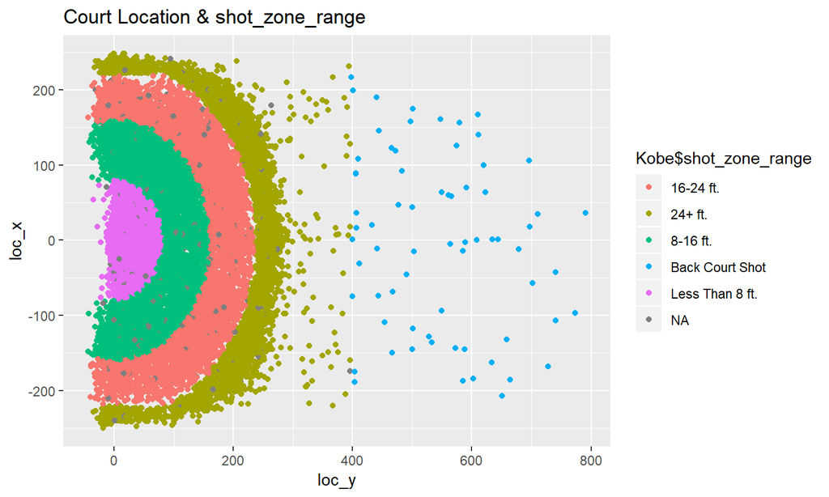

## Handling Missing Values

Methods

- Complete Case = Only complete cases were taken, Kobe_CC
- Median Imputation = Categorical values imputed with mode and numeric values imputed with median, Kobe_Med
- knn imputation = Categorical values imputed with mode and numeric valued imputed with data from similar observations, Kobe_knn

## Missing Values and Modeling

Performance of imputation methods in models

- Random Forest: Median > knn > Complete Cases
- GLMnet: Complete cases > knn > Median
- Decision Tree: knn > Complete Cases > Median (single variable), knn = Median > Complete Cases (multi variable)
- Neural Network: knn > Median > Complete Cases (single variable), knn > Completed Cases > Median (multi variable)

## Recoding

Recoded Variables

- Season was broken down into "90's", "2000-2005", "2006 - 2010", and "Post 2010"
- Oppenent broken down by conference into "Atlantic", "Southeast", "Central", "Northwest", "Northeast", "Pacific".
- Created 3 new subsets of the data, Kobe_Med_r, Kobe_knn_r, Kobe_CC_r, in addition to the original 3.

## Recoding and Modeling

Performance of recoding on models

- Random Forest: improved models slightly
- GLMnet: improved models across the board
- Decision Tree: made no difference in the models
- Neural Network: improved models accross the board

## Encoding

Encoded Categorical Variables

- Method 1: single variable encoding by changing variable to integer
- Method 2: multi variable encoding where new variables are created for each level of a variable
- Created 12 total versions of the data.

## Encoding and Modeling

Performance of encoding methods on models

- Random Forest: Single variable encoding best
- GLMnet: Multi variable encoding best
- Decision Tree: Multi variable encoding best
- Neural Network: Single variable encoding best

## Modeling

Ran a Random Forest, GLMnet, Decision Tree, and Neural Network on all 12 versions of data. Below is best version of each.

- Random Forest had Accuracy of .612286 : Median Imputed, Recoded, Single Variable Encoding
- GLMnet had Accuracy of .614779: Complete Cases, Recoded, Multi Variable Encoding
- Decision tree had Accuracy of .6117448: knn imputed, Recoded, Multi Variable Encoding
- Neural Network had accuracy of .612407: knn imputed, Recoded, Single Variable Encoding

## Tuning

Tuned best model (GLM Net) and got an accuracy of .6150474. Parameters were alpha of .4 and lambda of .000001.

Tuning Other models

- Best Random Forest increased to .61408 Accuracy when tuned.
- Best Decision Tree increased to .613846 Accuracy when tuned.
- Best Neural Network increased to .61334 Accuracy when tuned.

## Conclusion

While an accuracy of 61.50474% wasn't great we were able to:

- Improve our models with tuning
- See what data preparation techniques work best
- Lay a framework for any future studies done

Questions?

[figure not shown]